# I. Introduction

#### c. Actual Federal Funds Rate

##### 1. Vanilla RNN + Garch without Optimisation

```python
train_size = int(len(inde_var) * 0.8)
trainX, testX = inde_var[:train_size], inde_var[train_size:]
```

```python
trainY, testY = Actual_Rate[:train_size], Actual_Rate[train_size:]
```

```python
scaler_X = MinMaxScaler(feature_range=(0, 1))
scaler_y = MinMaxScaler(feature_range=(0, 1))

scaled_train_X = scaler_X.fit_transform(trainX)
scaled_train_y = scaler_y.fit_transform(trainY)
scaled_test_X = scaler_X.transform(testX)
scaled_test_y = scaler_y.transform(testY)
scaled_train = np.concatenate((scaled_train_X, scaled_train_y), axis=1)
scaled_test = np.concatenate((scaled_test_X, scaled_test_y), axis=1)
```

```python
# RNN Dataset Function
def create_dataset(data, look_back=1):

    X, Y = [], []

    for i in range(len(data) - look_back - 1):

        a = data[i:(i + look_back), :]
        X.append(a)

        Y.append(data[i + look_back, -1])

    return np.array(X), np.array(Y)
```

```python
look_back = 10

trainX, trainY = create_dataset(scaled_train, look_back)

testX, testY = create_dataset(scaled_test, look_back)
```

```python
# RNN Model
model = Sequential()
model.add(SimpleRNN(128, activation='relu'))
model.add(Dropout(0.2))
model.add(Dense(1, activation='linear'))

model.compile(optimizer='adam',
              loss='mean_squared_error',
              metrics=['mse'])

np.random.seed(1)
tf.random.set_seed(2)

model_rnn = model.fit(trainX,
                      trainY,
                      batch_size=60, epochs=100, shuffle=False, verbose=False)
```

```python
testPredict = model.predict(testX)
trainPredict = model.predict(trainX)
```

```python
trainPredict = scaler_y.inverse_transform(trainPredict)

trainY = scaler_y.inverse_transform([trainY])

testPredict = scaler_y.inverse_transform(testPredict)

testY = scaler_y.inverse_transform([testY])
```

```python
#RMSE
RNN_WOOpt_rmse = math.sqrt(mean_squared_error(testY[0], testPredict[:,0]))
print('RMSE: %.2f' % (testScore))

# MAE
RNN_WOOpt_mae = mean_absolute_error(testY[0], testPredict[:,0])
print('MAE: %.2f' % (testScore_MAE))

# r2
RNN_WOOpt_r2 = r2_score(testY[0], testPredict[:,0])
print('R2: %.2f' % (testScore_r2))
```

```
RMSE: 0.62
MAE: 0.36
R2: -13.99
```

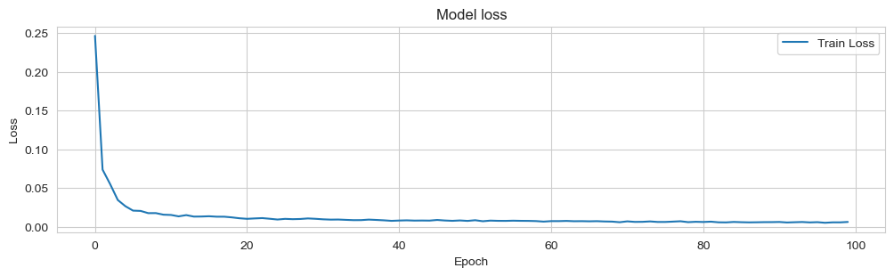

```python
# Draw the loss curve plot
plt.figure(figsize=(12, 3))
plt.plot(model_rnn.history['loss'], label='Train Loss')
plt.title('Model loss')
plt.ylabel('Loss')
plt.xlabel('Epoch')
plt.legend(loc='upper right')
plt.show()
```

```python
Real = pd.DataFrame(testY[0], columns=["Real"]).set_index(sasdate[-143:])
Predicted = pd.DataFrame(testPredict, columns=['Predicted']).set_index(sasdate[-143:])
```

```python
Data = pd.merge(Real, Predicted, on='sasdate')
```

```python
Data
```

| sasdate | Real | Predicted |
| --- | --- | --- |
| 2011-06-01 | -0.01 | 0.255419 |
| 2011-07-01 | 0.00 | 0.126025 |
| 2011-08-01 | -0.02 | -0.368051 |
| 2011-09-01 | 0.03 | -0.278518 |
| 2011-10-01 | -0.02 | -0.315149 |
| 2011-11-01 | -0.01 | -0.566302 |
| 2011-12-01 | 0.01 | -0.227102 |
| 2012-01-01 | -0.01 | 0.083024 |
| 2012-02-01 | 0.01 | -0.357933 |
| 2012-03-01 | 0.02 | 0.088849 |
| 2012-04-01 | 0.03 | 0.139665 |
| 2012-05-01 | 0.01 | -0.316811 |
| 2012-06-01 | 0.02 | -0.014463 |
| 2012-07-01 | 0.00 | -0.179974 |
| 2012-08-01 | 0.00 | -0.274246 |
| 2012-09-01 | -0.03 | -0.450822 |
| 2012-10-01 | 0.01 | -0.080266 |
| 2012-11-01 | 0.02 | -0.055923 |
| 2012-12-01 | 0.00 | 0.091295 |
| 2013-01-01 | 0.00 | 0.085953 |
| 2013-02-01 | -0.02 | -0.085840 |
| 2013-03-01 | 0.01 | -0.240306 |
| 2013-04-01 | -0.01 | 0.174202 |
| 2013-05-01 | 0.01 | 0.303424 |
| 2013-06-01 | -0.04 | 0.150344 |
| 2013-07-01 | -0.02 | -0.535325 |
| 2013-08-01 | 0.00 | 0.284281 |
| 2013-09-01 | -0.01 | 0.549130 |
| 2013-10-01 | 0.00 | -0.433233 |
| 2013-11-01 | 0.01 | -0.376127 |

[output cut: 113 more lines]

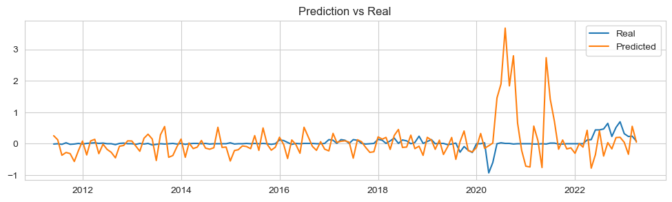

```python
plt.figure(figsize=(12, 3))
plt.plot(Data)
plt.title('Prediction vs Real')
plt.legend(['Real', 'Predicted'])
plt.show()
```

```python
RNN_WOOpt_results = {'Model': 'RNN without Optimisation',
                     'RMSE': RNN_WOOpt_rmse,
                     'R2': RNN_WOOpt_r2}
```

```python
best_results = pd.concat([best_results, pd.DataFrame([RNN_WOOpt_results])], ignore_index=True)
best_results
```

|  | Model | RMSE | R2 |
| --- | --- | --- | --- |
| 0 | Decision Tree with PCA | 1.175819 | -1.121575 |
| 1 | Random Forest Regression with PCA | 1.381059 | -1.926860 |
| 2 | Support Vector Regression | 1.402837 | -2.019898 |
| 3 | RNN without Optimisation | 0.621378 | -13.985326 |

##### 2. Vanilla RNN + Garch with Optimisation

```python
train_size = int(len(inde_var) * 0.8)
trainX, testX = inde_var[:train_size], inde_var[train_size:]
```

```python
trainY, testY = Actual_Rate[:train_size], Actual_Rate[train_size:]
```

```python
scaler_X = MinMaxScaler(feature_range=(0, 1))
scaler_y = MinMaxScaler(feature_range=(0, 1))
```

```python
scaled_train_X = scaler_X.fit_transform(trainX)
scaled_train_y = scaler_y.fit_transform(trainY)
scaled_test_X = scaler_X.transform(testX)
scaled_test_y = scaler_y.transform(testY)
scaled_train = np.concatenate((scaled_train_X, scaled_train_y), axis=1)
scaled_test = np.concatenate((scaled_test_X, scaled_test_y), axis=1)
```

```python
# RNN Dataset Function
def create_dataset(data, look_back=1):

    X, Y = [], []

    for i in range(len(data) - look_back - 1):

        a = data[i:(i + look_back), :]
        X.append(a)

        Y.append(data[i + look_back, -1])

    return np.array(X), np.array(Y)
```

```python
look_back = 10

trainX, trainY = create_dataset(scaled_train, look_back)

testX, testY = create_dataset(scaled_test, look_back)
```

```python
# Vanilla RNN Model
np.random.seed(1)
tf.random.set_seed(2)

model = Sequential()
model.add(SimpleRNN(128, activation='relu', kernel_initializer=HeNormal(), kernel_regularizer=l2(0.01)))
model.add(Dropout(0.2))
model.add(Dense(1, activation='linear'))

model.compile(optimizer='adam', loss='mean_squared_error', metrics=['mse'])

# Callbacks for training
early_stopping_cb = tf.keras.callbacks.EarlyStopping(patience=10, verbose=1)
lr_scheduler = tf.keras.callbacks.ReduceLROnPlateau(factor=0.5, patience=3, verbose=1)
```

```python
# Train the model with callbacks
model_rnn = model.fit(trainX,
                      trainY,
                      batch_size=64,
                      epochs=100,
                      shuffle=False,
                      validation_split=0.2,
                      callbacks=[early_stopping_cb, lr_scheduler],
                      verbose=1)
```

```python
testPredict = model.predict(testX)
trainPredict = model.predict(trainX)
```

```python
trainPredict = scaler_y.inverse_transform(trainPredict)

trainY = scaler_y.inverse_transform([trainY])

testPredict = scaler_y.inverse_transform(testPredict)

testY = scaler_y.inverse_transform([testY])
```

```python
#RMSE
RNN_WOpt_rmse = math.sqrt(mean_squared_error(testY[0], testPredict[:,0]))
print('RMSE: %.2f' % (RNN_WOpt_rmse))

# MAE
RNN_WOpt_mae = mean_absolute_error(testY[0], testPredict[:,0])
print('MAE: %.2f' % (RNN_WOpt_mae))

# r2
RNN_WOpt_r2 = r2_score(testY[0], testPredict[:,0])
print('R2: %.2f' % (RNN_WOpt_r2))
```

```
RMSE: 0.39
MAE: 0.26
R2: -4.91
```

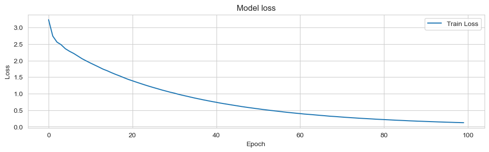

```python
# Draw the loss curve plot
plt.figure(figsize=(12, 3))
plt.plot(model_rnn.history['loss'], label='Train Loss')
plt.title('Model loss')
plt.ylabel('Loss')
plt.xlabel('Epoch')
plt.legend(loc='upper right')
plt.show()
```

```python
Real = pd.DataFrame(testY[0], columns=["Real"]).set_index(sasdate[-143:])
Predicted = pd.DataFrame(testPredict, columns=['Predicted']).set_index(sasdate[-143:])
```

```python
Data = pd.merge(Real, Predicted, on='sasdate')
```

```python
Data
```

| sasdate | Real | Predicted |
| --- | --- | --- |
| 2011-06-01 | -0.01 | 0.060506 |
| 2011-07-01 | 0.00 | 0.314560 |
| 2011-08-01 | -0.02 | -0.010195 |
| 2011-09-01 | 0.03 | 0.306683 |
| 2011-10-01 | -0.02 | -0.048287 |
| 2011-11-01 | -0.01 | 0.075369 |
| 2011-12-01 | 0.01 | -0.101178 |
| 2012-01-01 | -0.01 | 0.089555 |
| 2012-02-01 | 0.01 | -0.322711 |
| 2012-03-01 | 0.02 | 0.138272 |
| 2012-04-01 | 0.03 | 0.011341 |
| 2012-05-01 | 0.01 | 0.335996 |
| 2012-06-01 | 0.02 | 0.421495 |
| 2012-07-01 | 0.00 | 0.124824 |
| 2012-08-01 | 0.00 | 0.094198 |
| 2012-09-01 | -0.03 | -0.157278 |
| 2012-10-01 | 0.01 | -0.279212 |
| 2012-11-01 | 0.02 | -0.036345 |
| 2012-12-01 | 0.00 | 0.103070 |
| 2013-01-01 | 0.00 | 0.526905 |
| 2013-02-01 | -0.02 | 0.455655 |
| 2013-03-01 | 0.01 | 0.179088 |
| 2013-04-01 | -0.01 | 0.968071 |
| 2013-05-01 | 0.01 | 0.033914 |
| 2013-06-01 | -0.04 | -0.015615 |
| 2013-07-01 | -0.02 | -0.227698 |
| 2013-08-01 | 0.00 | 0.152711 |
| 2013-09-01 | -0.01 | 0.229260 |
| 2013-10-01 | 0.00 | 0.167434 |
| 2013-11-01 | 0.01 | 0.080122 |

[output cut: 113 more lines]

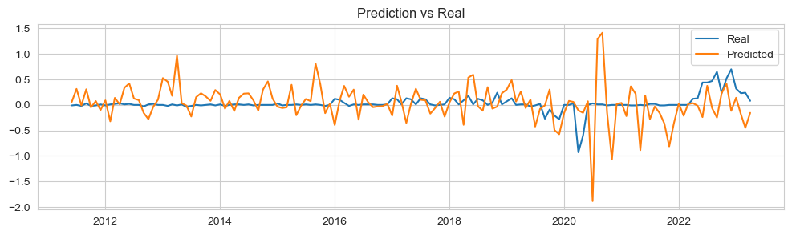

```python
plt.figure(figsize=(12, 3))
plt.plot(Data)
plt.title('Prediction vs Real')
plt.legend(['Real', 'Predicted'])
plt.show()
```

```python
RNN_WOpt_results = {'Model': 'RNN with Optimisation',
                    'RMSE': RNN_WOpt_rmse,
                    'R2': RNN_WOpt_r2}
```

```python
best_results = pd.concat([best_results, pd.DataFrame([RNN_WOpt_results])], ignore_index=True)
best_results
```

|  | Model | RMSE | R2 |
| --- | --- | --- | --- |
| 0 | Decision Tree with PCA | 1.175819 | -1.121575 |
| 1 | Random Forest Regression with PCA | 1.381059 | -1.926860 |
| 2 | Support Vector Regression | 1.402837 | -2.019898 |
| 3 | RNN without Optimisation | 0.621378 | -13.985326 |
| 4 | RNN with Optimisation | 0.390166 | -4.908181 |

#### d. Interest Rate Spread

##### 1. Vanilla RNN + Garch without Optimisation

```python
train_size = int(len(inde_var) * 0.8)
trainX, testX = inde_var[:train_size], inde_var[train_size:]
```

```python
trainY, testY = Rate_Spread[:train_size], Rate_Spread[train_size:]
```

```python
scaler_X = MinMaxScaler(feature_range=(0, 1))
scaler_y = MinMaxScaler(feature_range=(0, 1))
```

```python
scaled_train_X = scaler_X.fit_transform(trainX)
scaled_train_y = scaler_y.fit_transform(trainY)
scaled_test_X = scaler_X.transform(testX)
scaled_test_y = scaler_y.transform(testY)
scaled_train = np.concatenate((scaled_train_X, scaled_train_y), axis=1)
scaled_test = np.concatenate((scaled_test_X, scaled_test_y), axis=1)
```

```python
# RNN Dataset Function
def create_dataset(data, look_back=1):

    X, Y = [], []

    for i in range(len(data) - look_back - 1):

        a = data[i:(i + look_back), :]
        X.append(a)

        Y.append(data[i + look_back, -1])

    return np.array(X), np.array(Y)
```

```python
look_back = 10

trainX, trainY = create_dataset(scaled_train, look_back)

testX, testY = create_dataset(scaled_test, look_back)
```

```python
# RNN Model
model = Sequential()
model.add(SimpleRNN(128, activation='relu'))
model.add(Dropout(0.2))
model.add(Dense(1, activation='linear'))

model.compile(optimizer='adam',
              loss='mean_squared_error',
              metrics=['mse'])

np.random.seed(1)
tf.random.set_seed(2)

model_rnn = model.fit(trainX,
                      trainY,
                      batch_size=60, epochs=100, shuffle=False, verbose=False)
```

```python
history = model.fit(trainX, trainY, epochs=100, batch_size=32, verbose=1)
```

```python
trainPredict = model.predict(trainX)

testPredict = model.predict(testX)
```

```python
trainPredict = scaler_y.inverse_transform(trainPredict)

trainY = scaler_y.inverse_transform([trainY])

testPredict = scaler_y.inverse_transform(testPredict)

testY = scaler_y.inverse_transform([testY])
```

```python
#RMSE
testScore = math.sqrt(mean_squared_error(testY[0], testPredict[:,0]))
print('RMSE: %.2f' % (testScore))

# MAE
testScore_MAE = mean_absolute_error(testY[0], testPredict[:,0])
print('MAE: %.2f' % (testScore_MAE))

# r2
testScore_r2 = r2_score(testY[0], testPredict[:,0])
print('R2: %.2f' % (testScore_r2))
```

```
RMSE: 0.76
MAE: 0.36
R2: -31.51
```

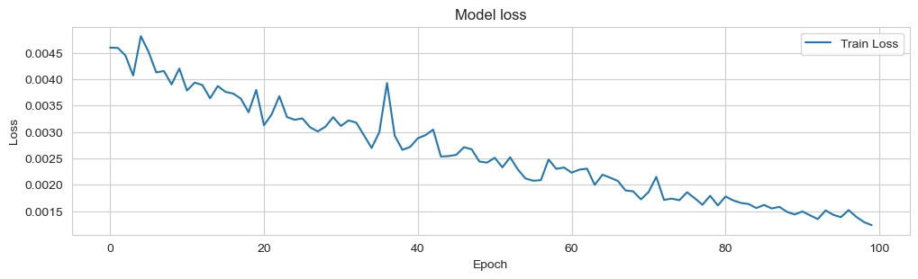

```python
plt.figure(figsize=(12, 3))
plt.plot(history.history['loss'], label='Train Loss')
plt.title('Model loss')
plt.ylabel('Loss')
plt.xlabel('Epoch')
plt.legend(loc='upper right')
plt.show()
```

```python
Real = pd.DataFrame(testY[0], columns=["Real"]).set_index(sasdate[-143:])
Predicted = pd.DataFrame(testPredict, columns=['Predicted']).set_index(sasdate[-143:])
```

```python
Data = pd.merge(Real, Predicted, on='sasdate')
Data
```

| sasdate | Real | Predicted |
| --- | --- | --- |
| 2011-06-01 | 0.03 | 0.456867 |
| 2011-07-01 | 0.01 | 0.080719 |
| 2011-08-01 | -0.02 | 0.025749 |
| 2011-09-01 | 0.05 | 0.165837 |
| 2011-10-01 | -0.05 | 0.173404 |
| 2011-11-01 | 0.01 | -0.235449 |
| 2011-12-01 | 0.02 | 0.355697 |
| 2012-01-01 | -0.02 | -0.076015 |
| 2012-02-01 | 0.02 | 0.016104 |
| 2012-03-01 | 0.01 | 0.255109 |
| 2012-04-01 | 0.01 | 0.389294 |
| 2012-05-01 | -0.02 | -0.070010 |
| 2012-06-01 | 0.01 | 0.293318 |
| 2012-07-01 | -0.02 | -0.169516 |
| 2012-08-01 | 0.00 | 0.028697 |
| 2012-09-01 | -0.03 | -0.264426 |
| 2012-10-01 | 0.04 | 0.052191 |
| 2012-11-01 | 0.01 | 0.244575 |
| 2012-12-01 | -0.02 | 0.107680 |
| 2013-01-01 | 0.00 | 0.211930 |
| 2013-02-01 | -0.02 | 0.237383 |
| 2013-03-01 | 0.03 | 0.076820 |
| 2013-04-01 | -0.02 | 0.176306 |
| 2013-05-01 | 0.02 | 0.170092 |
| 2013-06-01 | -0.05 | -0.119014 |
| 2013-07-01 | 0.02 | -0.355457 |
| 2013-08-01 | 0.02 | 0.553663 |
| 2013-09-01 | -0.01 | -0.015929 |
| 2013-10-01 | 0.01 | 0.358291 |
| 2013-11-01 | 0.01 | -0.223854 |

[output cut: 113 more lines]

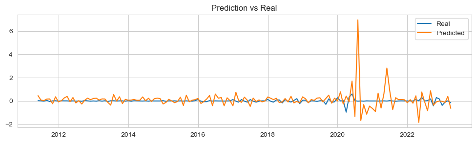

```python
plt.figure(figsize=(12, 3))
plt.plot(Data)
plt.title('Prediction vs Real')
plt.legend(['Real', 'Predicted'])
plt.show()
```

### E. LSTM

#### a. Actual Federal Funds Rate

##### 1. LSTM without optimisation

```python
train_size = int(len(inde_var) * 0.8)
trainX, testX = inde_var[:train_size], inde_var[train_size:]
```

```python
trainY, testY = Actual_Rate[:train_size], Actual_Rate[train_size:]
```

```python
scaler_X = MinMaxScaler(feature_range=(0, 1))
scaler_y = MinMaxScaler(feature_range=(0, 1))
```

```python
scaled_train_X = scaler_X.fit_transform(trainX)
scaled_train_y = scaler_y.fit_transform(trainY)
scaled_test_X = scaler_X.transform(testX)
scaled_test_y = scaler_y.transform(testY)
scaled_train = np.concatenate((scaled_train_X, scaled_train_y), axis=1)
scaled_test = np.concatenate((scaled_test_X, scaled_test_y), axis=1)
```

```python
# LSTM Dataset Function
def create_dataset(data, look_back=1):

    X, Y = [], []

    for i in range(len(data) - look_back - 1):

        a = data[i:(i + look_back), :]
        X.append(a)

        Y.append(data[i + look_back, -1])

    return np.array(X), np.array(Y)
```

```python
look_back = 10

trainX, trainY = create_dataset(scaled_train, look_back)

testX, testY = create_dataset(scaled_test, look_back)
```

```python
# LSTM model
model = Sequential()
model.add((LSTM(units=100, return_sequences=True)))
model.add((LSTM(100, return_sequences=False)))
model.add(Dropout(0.1))
model.add(Dense(1))
model.add(Activation('relu'))
model.compile(loss='mean_squared_error', optimizer='Adam')
```

```python
history = model.fit(trainX, trainY, epochs=100, batch_size=32, verbose=1)
```

```python
trainPredict = model.predict(trainX)

testPredict = model.predict(testX)
```

```python
trainPredict = scaler_y.inverse_transform(trainPredict)

trainY = scaler_y.inverse_transform([trainY])

testPredict = scaler_y.inverse_transform(testPredict)

testY = scaler_y.inverse_transform([testY])
```

```python
#RMSE
lstm_WOOpt_rmse = math.sqrt(mean_squared_error(testY[0], testPredict[:,0]))
print('RMSE: %.2f' % (lstm_WOOpt_rmse))

# MAE
lstm_WOOpt_mae = mean_absolute_error(testY[0], testPredict[:,0])
print('MAE: %.2f' % (lstm_WOOpt_mae))

# R2
lstm_WOOpt_r2 = r2_score(testY[0], testPredict[:,0])
print('MAE: %.2f' % (lstm_WOOpt_r2))
```

```
RMSE: 0.27
MAE: 0.17
MAE: -1.74
```

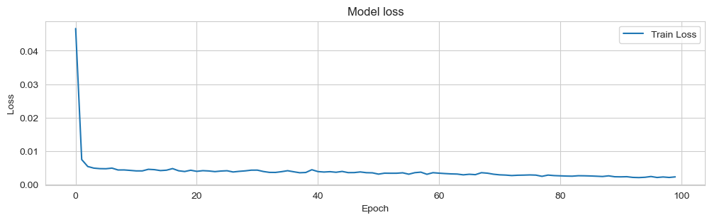

```python
plt.figure(figsize=(12, 3))
plt.plot(history.history['loss'], label='Train Loss')
plt.title('Model loss')
plt.ylabel('Loss')
plt.xlabel('Epoch')
plt.legend(loc='upper right')
plt.show()
```

```python
Real = pd.DataFrame(testY[0], columns=["Real"]).set_index(sasdate[-143:])
Predicted = pd.DataFrame(testPredict, columns=['Predicted']).set_index(sasdate[-143:])
```

```python
Data = pd.merge(Real, Predicted, on='sasdate')
Data
```

| sasdate | Real | Predicted |
| --- | --- | --- |
| 2011-06-01 | -0.01 | -0.280593 |
| 2011-07-01 | 0.00 | -0.161153 |
| 2011-08-01 | -0.02 | -0.227314 |
| 2011-09-01 | 0.03 | -0.140779 |
| 2011-10-01 | -0.02 | -0.080831 |
| 2011-11-01 | -0.01 | -0.204173 |
| 2011-12-01 | 0.01 | -0.148072 |
| 2012-01-01 | -0.01 | -0.066052 |
| 2012-02-01 | 0.01 | -0.050709 |
| 2012-03-01 | 0.02 | -0.034396 |
| 2012-04-01 | 0.03 | 0.049291 |
| 2012-05-01 | 0.01 | 0.098917 |
| 2012-06-01 | 0.02 | 0.101266 |
| 2012-07-01 | 0.00 | -0.053864 |
| 2012-08-01 | 0.00 | -0.194516 |
| 2012-09-01 | -0.03 | -0.301121 |
| 2012-10-01 | 0.01 | -0.060719 |
| 2012-11-01 | 0.02 | -0.077170 |
| 2012-12-01 | 0.00 | 0.083782 |
| 2013-01-01 | 0.00 | 0.007494 |
| 2013-02-01 | -0.02 | -0.030344 |
| 2013-03-01 | 0.01 | 0.020048 |
| 2013-04-01 | -0.01 | 0.307442 |
| 2013-05-01 | 0.01 | 0.104973 |
| 2013-06-01 | -0.04 | -0.138386 |
| 2013-07-01 | -0.02 | -0.219667 |
| 2013-08-01 | 0.00 | -0.013879 |
| 2013-09-01 | -0.01 | 0.061895 |
| 2013-10-01 | 0.00 | -0.050868 |
| 2013-11-01 | 0.01 | 0.014492 |

[output cut: 113 more lines]

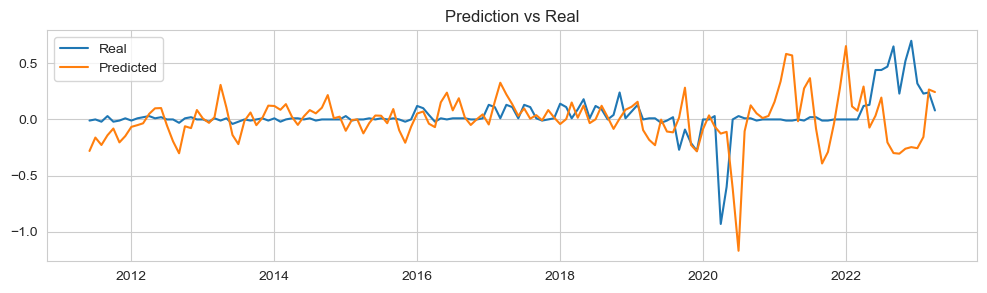

```python
plt.figure(figsize=(12, 3))
plt.plot(Data)
plt.title('Prediction vs Real')
plt.legend(['Real', 'Predicted'])
plt.show()
```

```python
lstm_WOOpt_results = {'Model': 'LSTM without Optimisation',
                      'RMSE': lstm_WOOpt_rmse,
                      'R2': lstm_WOOpt_r2}
```

```python
best_results = pd.concat([best_results, pd.DataFrame([lstm_WOOpt_results])], ignore_index=True)
best_results
```

|  | Model | RMSE | R2 |
| --- | --- | --- | --- |
| 0 | Decision Tree with PCA | 1.175819 | -1.121575 |
| 1 | Random Forest Regression with PCA | 1.381059 | -1.926860 |
| 2 | Support Vector Regression | 1.402837 | -2.019898 |
| 3 | RNN without Optimisation | 0.621378 | -13.985326 |
| 4 | RNN with Optimisation | 0.390166 | -4.908181 |
| 5 | LSTM without Optimisation | 0.265647 | -1.738818 |

##### 2. LSTM with optimisation

```python
train_size = int(len(inde_var) * 0.8)
trainX, testX = inde_var[:train_size], inde_var[train_size:]
```

```python
trainY, testY = Actual_Rate[:train_size], Actual_Rate[train_size:]
```

```python
scaler_X = MinMaxScaler(feature_range=(0, 1))
scaler_y = MinMaxScaler(feature_range=(0, 1))
```

```python
scaled_train_X = scaler_X.fit_transform(trainX)
scaled_train_y = scaler_y.fit_transform(trainY)
scaled_test_X = scaler_X.transform(testX)
scaled_test_y = scaler_y.transform(testY)
scaled_train = np.concatenate((scaled_train_X, scaled_train_y), axis=1)
scaled_test = np.concatenate((scaled_test_X, scaled_test_y), axis=1)
```

```python
# LSTM Dataset Function
def create_dataset(data, look_back=1):

    X, Y = [], []

    for i in range(len(data) - look_back - 1):

        a = data[i:(i + look_back), :]
        X.append(a)

        Y.append(data[i + look_back, -1])

    return np.array(X), np.array(Y)
```

```python
look_back = 10

trainX, trainY = create_dataset(scaled_train, look_back)

testX, testY = create_dataset(scaled_test, look_back)
```

```python
# LSTM model definition
model = Sequential()
model.add(LSTM(128, return_sequences=True, kernel_initializer=HeNormal(), kernel_regularizer=l2(0.01)))
model.add(LSTM(64, return_sequences=False, kernel_initializer=HeNormal(), kernel_regularizer=l2(0.01)))
model.add(Dropout(0.2))
model.add(Dense(1, activation='linear'))

# Compile the model with metrics
model.compile(loss='mean_squared_error', optimizer='adam', metrics=['mse'])

# Callbacks for training
early_stopping_cb = tf.keras.callbacks.EarlyStopping(patience=10, verbose=1)
lr_scheduler = tf.keras.callbacks.ReduceLROnPlateau(factor=0.5, patience=3, verbose=1)
```

```python
# Train the model with callbacks
model_lstm = model.fit(trainX,
                      trainY,
                      batch_size=32,
                      epochs=200,
                      shuffle=False,
                      validation_split=0.2,
                      callbacks=[early_stopping_cb, lr_scheduler],
                      verbose=1)
```

```
Epoch 72: ReduceLROnPlateau reducing learning rate to 0.0005000000237487257.
Epoch 76: ReduceLROnPlateau reducing learning rate to 0.0002500000118743628.
Epoch 80: ReduceLROnPlateau reducing learning rate to 0.0001250000059371814.
Epoch 83: ReduceLROnPlateau reducing learning rate to 6.25000029685907e-05.
Epoch 86: ReduceLROnPlateau reducing learning rate to 3.125000148429535e-05.
Epoch 89: ReduceLROnPlateau reducing learning rate to 1.5625000742147677e-05.
Epoch 92: ReduceLROnPlateau reducing learning rate to 7.812500371073838e-06.
Epoch 95: ReduceLROnPlateau reducing learning rate to 3.906250185536919e-06.
Epoch 97: early stopping
```

```python
trainPredict = model.predict(trainX)

testPredict = model.predict(testX)
```

```python
trainPredict = scaler_y.inverse_transform(trainPredict)

trainY = scaler_y.inverse_transform([trainY])

testPredict = scaler_y.inverse_transform(testPredict)

testY = scaler_y.inverse_transform([testY])
```

```python
#RMSE
lstm_WOpt_rmse = math.sqrt(mean_squared_error(testY[0], testPredict[:,0]))
print('RMSE: %.2f' % (lstm_WOpt_rmse))

# MAE
lstm_WOpt_mae = mean_absolute_error(testY[0], testPredict[:,0])
print('MAE: %.2f' % (lstm_WOpt_mae))

# R2
lstm_WOpt_r2 = r2_score(testY[0], testPredict[:,0])
print('R2: %.2f' % (lstm_WOpt_r2))
```

```
RMSE: 0.16
MAE: 0.08
R2: -0.05
```

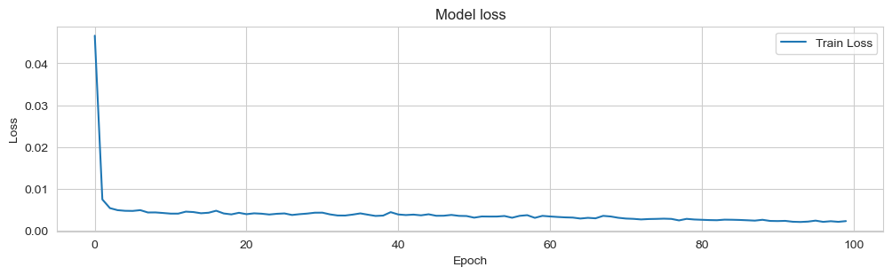

```python
plt.figure(figsize=(12, 3))
plt.plot(history.history['loss'], label='Train Loss')
plt.title('Model loss')
plt.ylabel('Loss')
plt.xlabel('Epoch')
plt.legend(loc='upper right')
plt.show()
```

```python
Real = pd.DataFrame(testY[0], columns=["Real"]).set_index(sasdate[-143:])
Predicted = pd.DataFrame(testPredict, columns=['Predicted']).set_index(sasdate[-143:])
```

```python
Data = pd.merge(Real, Predicted, on='sasdate')
Data
```

| sasdate | Real | Predicted |
| --- | --- | --- |
| 2011-06-01 | -0.01 | -0.016621 |
| 2011-07-01 | 0.00 | -0.016290 |
| 2011-08-01 | -0.02 | -0.016014 |
| 2011-09-01 | 0.03 | -0.016046 |
| 2011-10-01 | -0.02 | -0.016094 |
| 2011-11-01 | -0.01 | -0.016114 |
| 2011-12-01 | 0.01 | -0.015746 |
| 2012-01-01 | -0.01 | -0.015430 |
| 2012-02-01 | 0.01 | -0.015085 |
| 2012-03-01 | 0.02 | -0.014945 |
| 2012-04-01 | 0.03 | -0.015079 |
| 2012-05-01 | 0.01 | -0.014693 |
| 2012-06-01 | 0.02 | -0.014257 |
| 2012-07-01 | 0.00 | -0.013758 |
| 2012-08-01 | 0.00 | -0.013827 |
| 2012-09-01 | -0.03 | -0.013557 |
| 2012-10-01 | 0.01 | -0.013263 |
| 2012-11-01 | 0.02 | -0.013372 |
| 2012-12-01 | 0.00 | -0.012591 |
| 2013-01-01 | 0.00 | -0.013114 |
| 2013-02-01 | -0.02 | -0.013574 |
| 2013-03-01 | 0.01 | -0.013157 |
| 2013-04-01 | -0.01 | -0.012925 |
| 2013-05-01 | 0.01 | -0.012611 |
| 2013-06-01 | -0.04 | -0.011958 |
| 2013-07-01 | -0.02 | -0.011304 |
| 2013-08-01 | 0.00 | -0.011036 |
| 2013-09-01 | -0.01 | -0.011041 |
| 2013-10-01 | 0.00 | -0.011379 |
| 2013-11-01 | 0.01 | -0.011756 |

[output cut: 113 more lines]

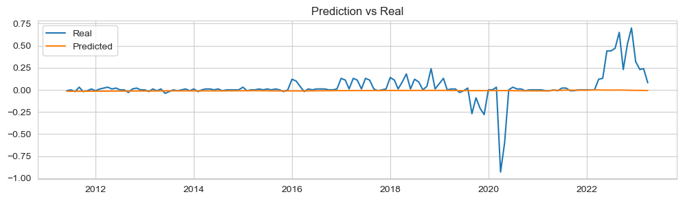

```python
plt.figure(figsize=(12, 3))
plt.plot(Data)
plt.title('Prediction vs Real')
plt.legend(['Real', 'Predicted'])
plt.show()
```

```python
lstm_WOpt_results = {'Model': 'LSTM with Optimisation',
                      'RMSE': lstm_WOpt_rmse,
                      'R2': lstm_WOpt_r2}
```

```python
best_results = pd.concat([best_results, pd.DataFrame([lstm_WOpt_results])], ignore_index=True)
best_results
```

|  | Model | RMSE | R2 |
| --- | --- | --- | --- |
| 0 | Decision Tree with PCA | 1.175819 | -1.121575 |
| 1 | Random Forest Regression with PCA | 1.381059 | -1.926860 |
| 2 | Support Vector Regression | 1.402837 | -2.019898 |
| 3 | RNN without Optimisation | 0.621378 | -13.985326 |
| 4 | RNN with Optimisation | 0.390166 | -4.908181 |
| 5 | LSTM without Optimisation | 0.265647 | -1.738818 |
| 6 | LSTM with Optimisation | 0.164592 | -0.051415 |

#### b. Interest Rate Spread

```python
train_size = int(len(inde_var) * 0.8)
trainX, testX = inde_var[:train_size], inde_var[train_size:]
```

```python
trainY, testY = Rate_Spread[:train_size], Rate_Spread[train_size:]
```

```python
scaler_X = MinMaxScaler(feature_range=(0, 1))
scaler_y = MinMaxScaler(feature_range=(0, 1))
```

```python
scaled_train_X = scaler_X.fit_transform(trainX)
scaled_train_y = scaler_y.fit_transform(trainY)
scaled_test_X = scaler_X.transform(testX)
scaled_test_y = scaler_y.transform(testY)
scaled_train = np.concatenate((scaled_train_X, scaled_train_y), axis=1)
scaled_test = np.concatenate((scaled_test_X, scaled_test_y), axis=1)
```

```python
# LSTM Dataset Function
def create_dataset(data, look_back=1):

    X, Y = [], []

    for i in range(len(data) - look_back - 1):

        a = data[i:(i + look_back), :]
        X.append(a)

        Y.append(data[i + look_back, -1])

    return np.array(X), np.array(Y)
```

```python
look_back = 10

trainX, trainY = create_dataset(scaled_train, look_back)

testX, testY = create_dataset(scaled_test, look_back)
```

```python
# LSTM model
model = Sequential()
model.add((LSTM(units=100, return_sequences=True)))
model.add((LSTM(100, return_sequences=False)))
model.add(Dropout(0.1))
model.add(Dense(1))
model.add(Activation('relu'))
model.compile(loss='mean_squared_error', optimizer='Adam')
```

```python
history = model.fit(trainX, trainY, epochs=100, batch_size=32, verbose=1)
```

```python
trainPredict = model.predict(trainX)

testPredict = model.predict(testX)
```

```python
trainPredict = scaler_y.inverse_transform(trainPredict)

trainY = scaler_y.inverse_transform([trainY])

testPredict = scaler_y.inverse_transform(testPredict)

testY = scaler_y.inverse_transform([testY])
```

```python
#RMSE
testScore = math.sqrt(mean_squared_error(testY[0], testPredict[:,0]))
print('RMSE: %.2f' % (testScore))

# MAE
testScore_MAE = mean_absolute_error(testY[0], testPredict[:,0])
print('MAE: %.2f' % (testScore_MAE))
```

```
RMSE: 0.40
MAE: 0.27
```

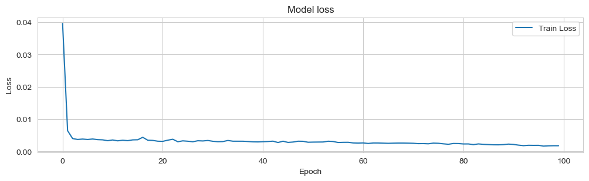

```python
plt.figure(figsize=(12, 3))
plt.plot(history.history['loss'], label='Train Loss')
plt.title('Model loss')
plt.ylabel('Loss')
plt.xlabel('Epoch')
plt.legend(loc='upper right')
plt.show()
```

```python
Real = pd.DataFrame(testY[0], columns=["Real"]).set_index(sasdate[-143:])
Predicted = pd.DataFrame(testPredict, columns=['Predicted']).set_index(sasdate[-143:])
```

```python
Data = pd.merge(Real, Predicted, on='sasdate')
```

```python
Data
```

| sasdate | Real | Predicted |
| --- | --- | --- |
| 2011-06-01 | 0.03 | -0.154877 |
| 2011-07-01 | 0.01 | 0.060760 |
| 2011-08-01 | -0.02 | -0.231906 |
| 2011-09-01 | 0.05 | 0.118083 |
| 2011-10-01 | -0.05 | -0.279141 |
| 2011-11-01 | 0.01 | -0.066406 |
| 2011-12-01 | 0.02 | -0.050781 |
| 2012-01-01 | -0.02 | 0.209103 |
| 2012-02-01 | 0.02 | 0.250613 |
| 2012-03-01 | 0.01 | 0.063049 |
| 2012-04-01 | 0.01 | -0.001670 |
| 2012-05-01 | -0.02 | 0.215106 |
| 2012-06-01 | 0.01 | 0.020864 |
| 2012-07-01 | -0.02 | -0.243059 |
| 2012-08-01 | 0.00 | -0.180259 |
| 2012-09-01 | -0.03 | -0.614238 |
| 2012-10-01 | 0.04 | 0.048761 |
| 2012-11-01 | 0.01 | 0.211900 |
| 2012-12-01 | -0.02 | 0.464103 |
| 2013-01-01 | 0.00 | -0.051293 |
| 2013-02-01 | -0.02 | -0.077092 |
| 2013-03-01 | 0.03 | -0.255251 |
| 2013-04-01 | -0.02 | 0.280142 |
| 2013-05-01 | 0.02 | 0.330582 |
| 2013-06-01 | -0.05 | -0.037895 |
| 2013-07-01 | 0.02 | -0.192799 |
| 2013-08-01 | 0.02 | 0.209970 |
| 2013-09-01 | -0.01 | -0.188952 |
| 2013-10-01 | 0.01 | -0.057090 |
| 2013-11-01 | 0.01 | -0.012955 |

[output cut: 113 more lines]

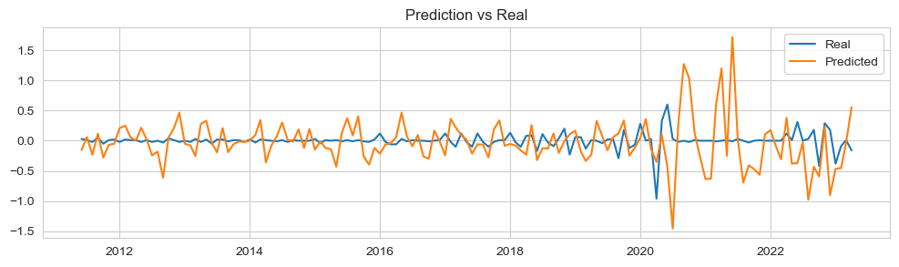

```python
plt.figure(figsize=(12, 3))
plt.plot(Data)
plt.title('Prediction vs Real')
plt.legend(['Real', 'Predicted'])
plt.show()
```

## vi. ML Conclusion

### A. Dimensionality Reduction

```python
final_results
```

|  | Model | R-Squared | MSE | Time |
| --- | --- | --- | --- | --- |
| 0 | OLS | -6.845652 | 0.603126 | 2.325707 |
| 1 | OLS with PCA | -10.952001 | 0.739855 | 0.660926 |
| 2 | OLS with PCA in EN Reg. | -0.072702 | 0.221649 | 2.587655 |
| 3 | OLS with PCA in EN Reg. in S.W. | -0.072877 | 0.221667 | 1.376456 |
| 4 | OLS with RFE | -4.133048 | 0.484858 | 106.512999 |
| 5 | OLS with RFE in EN Reg. | -0.077381 | 0.222132 | 107.446670 |
| 6 | OLS with RFE in EN Reg. in S.W. | -0.067880 | 0.221150 | 37.971492 |

#### Recap

According to the training time, RFE takes the longest time; While PCA and SelectKBest are similar. Also, in terms of the multicollinearity issue, RFE might not be the best approach since RFE mainly focus on finding the features with highest attribute e.g. coefficient estimates, which does not contribute to eliminating the multicollinearity issue in each procedure, until n features have been selected [1]. Hence, if there are 3 features with really high, or even perfect multicollinearity issue, but having high contribution to the y prediction, RFE suppose cannot help with this issue. Only the least important features are pruned. So, considering the computational cost and ability to tackle multicollinearity issue, we do NOT use RFE.

Alternatively, for SelectKBest, despite the computational cost being less high, for our regression task, it is using F-stat, which measures how well a feature explains the variance in the target variable relative to the variance explained by other features. [2] discusses how multicollinearity affects t-statistics but mentions that it does not directly affect the F-statistic. This indicates that while feature selection methods like SelectKBest may help identify important features, they do not resolve underlying multicollinearity issues.

Therefore, we are only using PCA to tackle the multicolinearity issue, instead of RFE and SelectKBest.

[1] https://www.analyticsvidhya.com/blog/2023/05/recursive-feature-elimination/#:~:text=RFE%20can%20handle%20multicollinearity%20but,can%20also%20deal%20with%20multicollinearity.

[2] https://www.analystforum.com/t/multicollinearity-and-f-stat/52731

### B. Classification Tasks

```python
class_final_results
```

|  | Model | Accuracy | Precision | Recall | F1 Score | ROC | Time Required |
| --- | --- | --- | --- | --- | --- | --- | --- |
| 0 | Logistic Regression | 0.422078 | 0.449694 | 0.422078 | 0.431881 | 0.584569 | 0.287971 |
| 1 | Decision Tree Classifier | 0.402597 | 0.470338 | 0.402597 | 0.417460 | 0.580923 | 0.097049 |
| 2 | SGD Classifier | 0.454545 | 0.482376 | 0.454545 | 0.457457 | 0.583508 | 0.173469 |
| 3 | SVM | 0.454545 | 0.482376 | 0.454545 | 0.457457 | 0.583508 | 0.167402 |
| 4 | XGBoost Classifier | 0.532468 | 0.535923 | 0.532468 | 0.530071 | 0.696564 | 0.643396 |

#### Recap

##### Logistic Regression

Before and after SMOTE class redistribution,

| Model | Accuracy | Precision | Recall | F1 Score | ROC |
| --- | --- | --- | --- | --- | --- |
| Logistic Regression | 0.487013 | 0.41959 | 0.487013 | 0.43032 | 0.595458 |
| Logistic Regression after SMOTE | 0.422078 | 0.449694 | 0.422078 | 0.431881 | 0.584569 |

As we observe, the accuracy is decreased, which is normal since class imbalance would produce biased prediction, like predicting mostly 1 and -1 instead of 0. As a result, the precision ("Out of the fish we have caught, how many of this is actually fish") would be **lower before SMOTE**. As a result, the F1 score in this logistic regression after SMOTE is slightly higher as well.

##### Decision Tree Classifier

Before and after SMOTE class redistribution,

| Model | Accuracy | Precision | Recall | F1 Score | ROC |
| --- | --- | --- | --- | --- | --- |
| Decision Tree Classifier | 0.38961 | 0.285561 | 0.38961 | 0.329518 | 0.544689 |
| Decision Tree Classifier (after SMOTE) | 0.402597 | 0.470338 | 0.402597 | 0.41746 | 0.580923 |

As we can see, after the SMOTE redistribution, the Decision Tree Classifier's f1 score is **much higher**, and the accuracy is higher as well.

##### SGD Classifier

Before and after SMOTE class redistribution & Reset the alpha,

| Model | Accuracy | Precision | Recall | F1 Score | ROC |
| --- | --- | --- | --- | --- | --- |
| SGD Classifier | 0.519481 | 0.377195 | 0.519481 | 0.437035 | 0.610604 |
| SGD Classifier (after SMOTE) | 0.454545 | 0.482376 | 0.454545 | 0.457457 | 0.583508 |

As we observe, after re-adjusting the alpha value to higher, having higher penalty, the f1 score slightly increase ~2%, with Precision much higher than before. This implies our model can classifier each class more accurately.

##### Support Vector Machine

Before and after SMOTE class redistribution,

| Model | Accuracy | Precision | Recall | F1 Score | ROC |
| --- | --- | --- | --- | --- | --- |
| SVM | 0.519481 | 0.377195 | 0.519481 | 0.437035 | 0.610604 |
| SVM (after SMOTE) | 0.454545 | 0.482376 | 0.454545 | 0.457457 | 0.583508 |

As we observe, f1 score is higher, with precisionbeing much higher.

##### XGBoost

Before and after SMOTE class redistribution,

| Model | Accuracy | Precision | Recall | F1 Score | ROC |
| --- | --- | --- | --- | --- | --- |
| XGBoost | 0.506494 | 0.366176 | 0.506494 | 0.424910 | 0.650393 |
| XGBoost (after SMOTE) | 0.532468 | 0.535923 | 0.532468 | 0.530071 | 0.696564 |

As we observe, F1 score is much higher after SMOTE, with accuracy having improvement as well. Basically all metrics have improvement after SMOTE in XGBoost Classifier

After SMOTE class redistribution, it seems like all models have a better f1 score.

Among them, XGBoost after SMOTE peforms the best out of all models, in terms of accuracy, f1 score or ROC

### C. Regression Tasks

```python
best_results
```

|  | Model | RMSE | R2 |
| --- | --- | --- | --- |
| 0 | Decision Tree with PCA | 1.175819 | -1.121575 |
| 1 | Random Forest Regression with PCA | 1.381059 | -1.926860 |
| 2 | Support Vector Regression | 1.402837 | -2.019898 |
| 3 | RNN without Optimisation | 0.621378 | -13.985326 |
| 4 | RNN with Optimisation | 0.390166 | -4.908181 |
| 5 | LSTM without Optimisation | 0.265647 | -1.738818 |
| 6 | LSTM with Optimisation | 0.164592 | -0.051415 |

In conclusion, for normal, traditional models, Decision Tree might be the best. While for Deep Learning model, depending on computational cost, RNN with optimisation or vanilla LSTM would be a nice choice.